# Day 2

Solberg, O. M:

2022-09-27

# Day 2

## Paste function

```r
paste("my vector", c("one", "two", "three"))
```

```
## [1] "my vector one"   "my vector two"   "my vector three"
```

You can collapse the vector to one continues string, seperated by what you define in the brackets.

```r
a <- paste("my vector", c("one", "two", "three"), collapse = "-")
print(a)
```

```
## [1] "my vector one-my vector two-my vector three"
```

The paste function can also vectorize the operation if multiple arguments is passed

```r
paste("X", 1:7, sep = "")
```

```
## [1] "X1" "X2" "X3" "X4" "X5" "X6" "X7"
```

```r
paste(c("X","Y"), 1:6, sep = "")
```

```
## [1] "X1" "Y2" "X3" "Y4" "X5" "Y6"
```

## For loops

```r
S <- c("some", "character", "for", "the", "example")
S [3]
```

```
## [1] "for"
```

```r
for (b in 1:5){
  print (S[b])
  }
```

```
## [1] "some"
## [1] "character"
## [1] "for"
## [1] "the"
## [1] "example"
```

## RDS is used for saving and loading data

```r
data("iris")
saveRDS(iris, file = "testdata.RDS")
```

## LS

The ls function list all the objects that is currently loaded in to global enviroment

```r
ls()
```

```
## [1] "a"    "b"    "iris" "S"
```

Removes everything from the global enviroment

```r
rm(list = ls())
```

## CSV

Every row of the data ends with a new line

```r
read.csv
```

```
## function (file, header = TRUE, sep = ",", quote = "\"", dec = ".",
##     fill = TRUE, comment.char = "", ...)
## read.table(file = file, header = header, sep = sep, quote = quote,
##     dec = dec, fill = fill, comment.char = comment.char, ...)
## <bytecode: 0x7ffbe3142e00>
## <environment: namespace:utils>
```

```r
data("iris")
write.csv(iris, file = "iristest.csv")
```

Unlink

```r
unlink("iristest.csv")
```

Assigning file into DF

```r
assign(x = "df2", value = "testdata.RDS")
```

Getting information about the dataset

```r
dim(airquality)
```

```
## [1] 153   6
```

```r
str(airquality)
```

```
## 'data.frame':    153 obs. of  6 variables:
##  $ Ozone  : int  41 36 12 18 NA 28 23 19 8 NA ...
##  $ Solar.R: int  190 118 149 313 NA NA 299 99 19 194 ...
##  $ Wind   : num  7.4 8 12.6 11.5 14.3 14.9 8.6 13.8 20.1 8.6 ...
##  $ Temp   : int  67 72 74 62 56 66 65 59 61 69 ...
##  $ Month  : int  5 5 5 5 5 5 5 5 5 5 ...
##  $ Day    : int  1 2 3 4 5 6 7 8 9 10 ...
```

```r
data("airquality")
subset(airquality, Temp > 80, select = c(Ozone, Temp))
```

```
##     Ozone Temp
## 29     45   81
## 35     NA   84
## 36     NA   85
## 38     29   82
## 39     NA   87
## 40     71   90
## 41     39   87
## 42     NA   93
## 43     NA   92
## 44     23   82
## 61     NA   83
## 62    135   84
## 63     49   85
## 64     32   81
```

[output cut: 54 more lines]

## Reading stata

```r
library(readstata13)
library(foreign)
library(haven)

#df <- readstata13::read.dta13("path/to/file.dta")
```

## Reading SPSS

```r
library(foreign)
#df <- foreign::read.spss("path/to/file.dta")
```

## Reading Excel

Easy to get data from Excel to R support xls and xlsx

```r
library(readxl)
#df <- readxl::read_excel("path/to/file.dta", sheet = 1)
```

readxl includes several example files, which we use throughout the documentation. Use the helper readxl_example() with no arguments to list them or call it with an example filename to get the path.

read_excel() reads both xls and xlsx files and detects the format from the extension.

```r
library(readxl)
readxl_example()
```

```
##  [1] "clippy.xls"    "clippy.xlsx"   "datasets.xls"  "datasets.xlsx"
##  [5] "deaths.xls"    "deaths.xlsx"   "geometry.xls"  "geometry.xlsx"
##  [9] "type-me.xls"   "type-me.xlsx"
```

```r
readxl_example("clippy.xls")
```

```
## [1] "/Library/Frameworks/R.framework/Versions/4.2/Resources/library/readxl/extdata/clippy.xls"
```

```r
xlsx_example <- readxl_example("datasets.xlsx")
read_excel(xlsx_example)
```

```
## # A tibble: 150 × 5
##    Sepal.Length Sepal.Width Petal.Length Petal.Width Species
##           <dbl>       <dbl>        <dbl>       <dbl> <chr>
##  1          5.1         3.5          1.4         0.2 setosa
##  2          4.9         3            1.4         0.2 setosa
##  3          4.7         3.2          1.3         0.2 setosa
##  4          4.6         3.1          1.5         0.2 setosa
##  5          5           3.6          1.4         0.2 setosa
##  6          5.4         3.9          1.7         0.4 setosa
##  7          4.6         3.4          1.4         0.3 setosa
##  8          5           3.4          1.5         0.2 setosa
##  9          4.4         2.9          1.4         0.2 setosa
## 10          4.9         3.1          1.5         0.1 setosa
## # … with 140 more rows
```

´ List the sheet names with excel_sheets().

```r
excel_sheets(xlsx_example)
```

```
## [1] "iris"     "mtcars"   "chickwts" "quakes"
```

Specify a worksheet by name or number.

```r
read_excel(xlsx_example, sheet = "chickwts")
```

```
## # A tibble: 71 × 2
##    weight feed
##     <dbl> <chr>
##  1    179 horsebean
##  2    160 horsebean
##  3    136 horsebean
##  4    227 horsebean
##  5    217 horsebean
##  6    168 horsebean
##  7    108 horsebean
##  8    124 horsebean
##  9    143 horsebean
## 10    140 horsebean
## # … with 61 more rows
```

```r
read_excel(xlsx_example, sheet = 4)
```

```
## # A tibble: 1,000 × 5
##      lat  long depth   mag stations
##    <dbl> <dbl> <dbl> <dbl>    <dbl>
##  1 -20.4  182.   562   4.8       41
##  2 -20.6  181.   650   4.2       15
##  3 -26    184.    42   5.4       43
##  4 -18.0  182.   626   4.1       19
##  5 -20.4  182.   649   4         11
##  6 -19.7  184.   195   4         12
##  7 -11.7  166.    82   4.8       43
##  8 -28.1  182.   194   4.4       15
##  9 -28.7  182.   211   4.7       35
## 10 -17.5  180.   622   4.3       19
## # … with 990 more rows
```

There are various ways to control which cells are read. You can even specify the sheet here, if providing an Excel-style cell range.

```r
read_excel(xlsx_example, n_max = 3)
```

```
## # A tibble: 3 × 5
##   Sepal.Length Sepal.Width Petal.Length Petal.Width Species
##          <dbl>       <dbl>        <dbl>       <dbl> <chr>
## 1          5.1         3.5          1.4         0.2 setosa
## 2          4.9         3            1.4         0.2 setosa
## 3          4.7         3.2          1.3         0.2 setosa
```

```r
read_excel(xlsx_example, range = "C1:E4")
```

```
## # A tibble: 3 × 3
##   Petal.Length Petal.Width Species
##          <dbl>       <dbl> <chr>
## 1          1.4         0.2 setosa
## 2          1.4         0.2 setosa
## 3          1.3         0.2 setosa
```

```r
read_excel(xlsx_example, range = cell_rows(1:4))
```

```
## # A tibble: 3 × 5
##   Sepal.Length Sepal.Width Petal.Length Petal.Width Species
##          <dbl>       <dbl>        <dbl>       <dbl> <chr>
## 1          5.1         3.5          1.4         0.2 setosa
## 2          4.9         3            1.4         0.2 setosa
## 3          4.7         3.2          1.3         0.2 setosa
```

```r
read_excel(xlsx_example, range = cell_cols("B:D"))
```

```
## # A tibble: 150 × 3
##    Sepal.Width Petal.Length Petal.Width
##          <dbl>        <dbl>       <dbl>
##  1         3.5          1.4         0.2
##  2         3            1.4         0.2
##  3         3.2          1.3         0.2
##  4         3.1          1.5         0.2
##  5         3.6          1.4         0.2
##  6         3.9          1.7         0.4
##  7         3.4          1.4         0.3
##  8         3.4          1.5         0.2
##  9         2.9          1.4         0.2
## 10         3.1          1.5         0.1
## # … with 140 more rows
```

```r
read_excel(xlsx_example, range = "mtcars!B1:D5")
```

```
## # A tibble: 4 × 3
##     cyl  disp    hp
##   <dbl> <dbl> <dbl>
## 1     6   160   110
## 2     6   160   110
## 3     4   108    93
## 4     6   258   110
```

If NAs are represented by something other than blank cells, set the na argument.

```r
read_excel(xlsx_example, na = "setosa")
```

```
## # A tibble: 150 × 5
##    Sepal.Length Sepal.Width Petal.Length Petal.Width Species
##           <dbl>       <dbl>        <dbl>       <dbl> <chr>
##  1          5.1         3.5          1.4         0.2 <NA>
##  2          4.9         3            1.4         0.2 <NA>
##  3          4.7         3.2          1.3         0.2 <NA>
##  4          4.6         3.1          1.5         0.2 <NA>
##  5          5           3.6          1.4         0.2 <NA>
##  6          5.4         3.9          1.7         0.4 <NA>
##  7          4.6         3.4          1.4         0.3 <NA>
##  8          5           3.4          1.5         0.2 <NA>
##  9          4.4         2.9          1.4         0.2 <NA>
## 10          4.9         3.1          1.5         0.1 <NA>
## # … with 140 more rows
```

```r
data("airquality")
haven::write_sav(data=airquality, path="airquality.sav")
```

[output not shown]

[output not shown]

```r
library(pander)
pander(head(df))
```

| Ozone | Solar.R | Wind | Temp | Month | Day |
| --- | --- | --- | --- | --- | --- |
| 41 | 190 | 7.4 | 67 | 5 | 1 |
| 36 | 118 | 8 | 72 | 5 | 2 |
| 12 | 149 | 12.6 | 74 | 5 | 3 |
| 18 | 313 | 11.5 | 62 | 5 | 4 |
| NA | NA | 14.3 | 56 | 5 | 5 |
| 28 | NA | 14.9 | 66 | 5 | 6 |

## Is na

```r
#data(attenu)
#is.na(attenu)
```

## If

```r
data("attenu")

if (is.numeric(attenu$event)) {
print(mean(attenu$event))
}else {print("not a number")}
```

```
## [1] 14.74176
```

## Plot

col = color pch gives the type of marker cex gives the size of marker

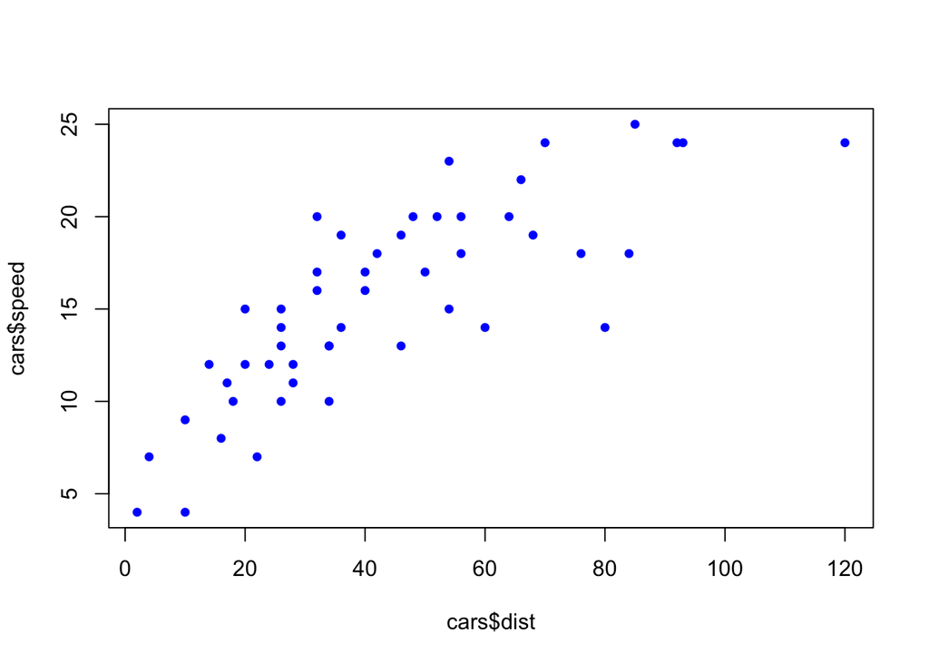

```r
plot(cars$dist, cars$speed, col = "blue", cex = 0.9, pch = 16)
```

## NCHAR

finds the number of character in a string

```r
fn <- "tofu"
nchar(fn)
```

```
## [1] 4
```

## Splitting a string

```r
strsplit(x = "cooked tofu", split =" ")
```

```
## [[1]]
## [1] "cooked" "tofu"
```

```r
state.name
```

```
##  [1] "Alabama"        "Alaska"         "Arizona"        "Arkansas"
##  [5] "California"     "Colorado"       "Connecticut"    "Delaware"
##  [9] "Florida"        "Georgia"        "Hawaii"         "Idaho"
## [13] "Illinois"       "Indiana"        "Iowa"           "Kansas"
## [17] "Kentucky"       "Louisiana"      "Maine"          "Maryland"
## [21] "Massachusetts"  "Michigan"       "Minnesota"      "Mississippi"
## [25] "Missouri"       "Montana"        "Nebraska"       "Nevada"
## [29] "New Hampshire"  "New Jersey"     "New Mexico"     "New York"
## [33] "North Carolina" "North Dakota"   "Ohio"           "Oklahoma"
## [37] "Oregon"         "Pennsylvania"   "Rhode Island"   "South Carolina"
## [41] "South Dakota"   "Tennessee"      "Texas"          "Utah"
## [45] "Vermont"        "Virginia"       "Washington"     "West Virginia"
## [49] "Wisconsin"      "Wyoming"
```

```r
substring (state.name,1,3)
```

```
##  [1] "Ala" "Ala" "Ari" "Ark" "Cal" "Col" "Con" "Del" "Flo" "Geo" "Haw" "Ida"
## [13] "Ill" "Ind" "Iow" "Kan" "Ken" "Lou" "Mai" "Mar" "Mas" "Mic" "Min" "Mis"
## [25] "Mis" "Mon" "Neb" "Nev" "New" "New" "New" "New" "Nor" "Nor" "Ohi" "Okl"
## [37] "Ore" "Pen" "Rho" "Sou" "Sou" "Ten" "Tex" "Uta" "Ver" "Vir" "Was" "Wes"
## [49] "Wis" "Wyo"
```

## StringR

```r
#library(stringr)
#str_detect()
#str_count()
#str_subset()
#str_locate()
#str_exact()
#str_match()
#str_replace()
```

## which

Tells the position of the condition if true.

```r
which(LETTERS == "R")
```

```
## [1] 18
```

devtools::install_github(“gadenbuie/regexplain”)

hagish@uio.no